# Лабораторная работа №9

по курсу: Архитектура компьютера и опреационные системы

Иванова Анастасия Сергеевна

1132250427@rudn.ru

Российский университет дружбы народов

2026-04-11

# Докладчик

- Иванова Анастасия Сергеевна
- 1 курс группа НКАбд-07-25
- Российский университет дружбы народов
- 1132250427@rudn.ru

# Вводная часть

## Актуальность темы

- Midnight Commander (mc) является одной из самых популярных псевдографических файловых оболочек для UNIX/Linux систем
- Позволяет эффективно работать с файловой системой в среде командной строки без использования графического интерфейса
- Значительно ускоряет выполнение рутинных операций с файлами и каталогами
- Встроенный редактор и возможности настройки делают mc универсальным инструментом для администрирования и разработки
- Понимание работы mc необходимо для профессиональной работы в Linux-среде

## Объект и предмет исследования

**Объект исследования:** - Командная оболочка Midnight Commander - Файловая система операционной системы Linux - Интерфейс взаимодействия пользователя с ОС посредством псевдографической оболочки

**Предмет исследования:** - Операции с файлами и каталогами в mc - Настройка внешнего вида и поведения mc - Работа со встроенным редактором mc - Управление панелями и режимами отображения

## Цели

- Освоение основных возможностей командной оболочки Midnight Commander
- Приобретение навыков практической работы по просмотру каталогов и файлов; манипуляций с ними.

# **Выполнение лабораторной работы**

**1. Изучим информацию о mc, вызвав в командной строке man mc.**

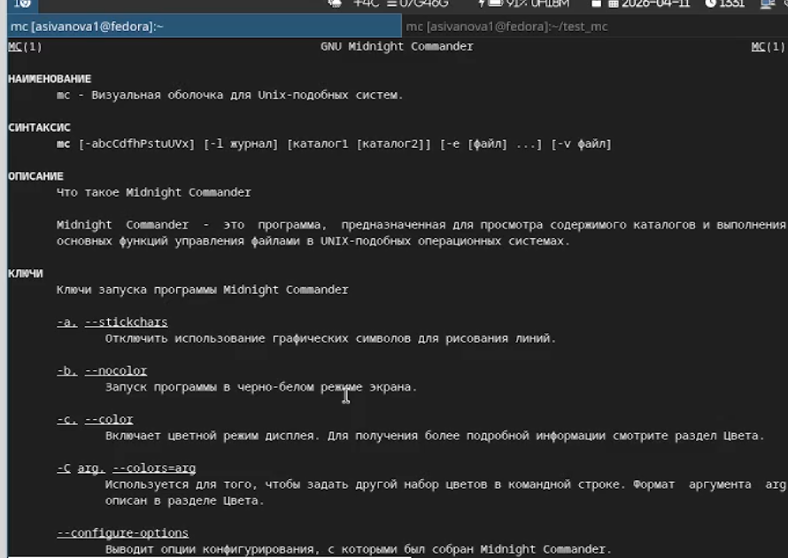

Рисунок 1: Информация о команде

**2. Запустим из командной строки mc, изучим его структуру и меню.**

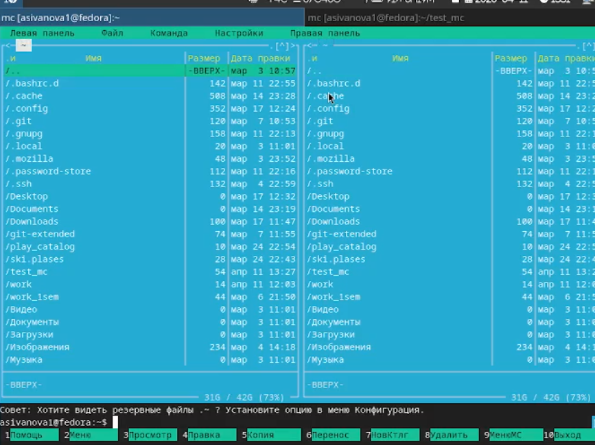

Рисунок 2: Запуск

**3. Выполним несколько операций в mc, используя управляющие клавиши (смена панелей, отключение панелей)**

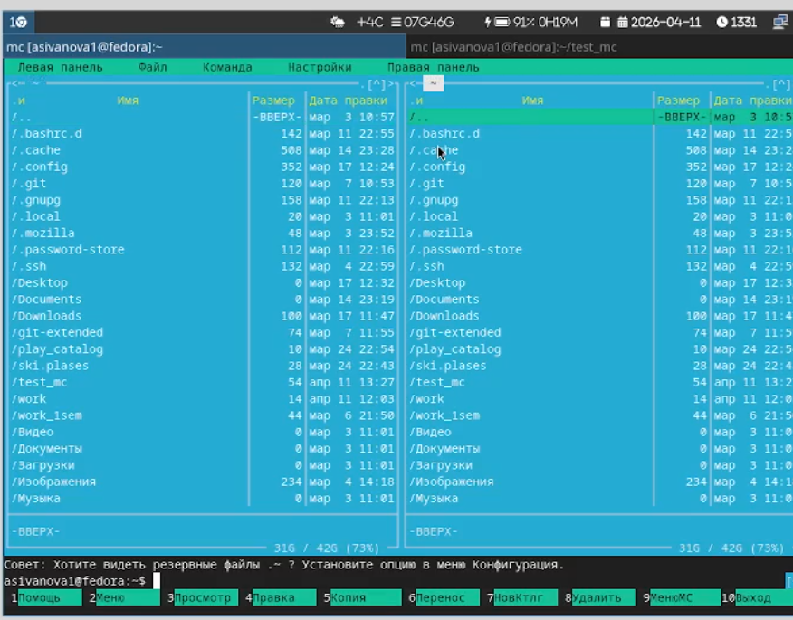

Рисунок 3: Выполнение

**4. Используя возможности подменю Файл**

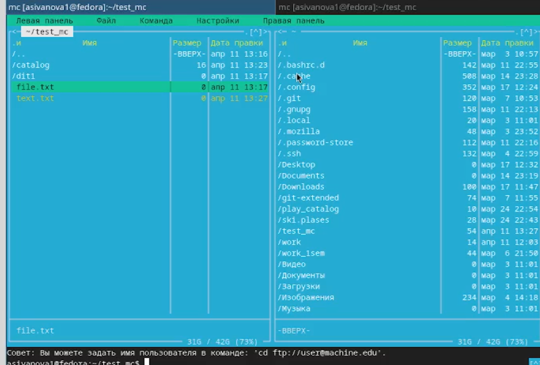

Рисунок 4: Каталог

**Выполним:**

```
- просмотр содержимого текстового файла
```

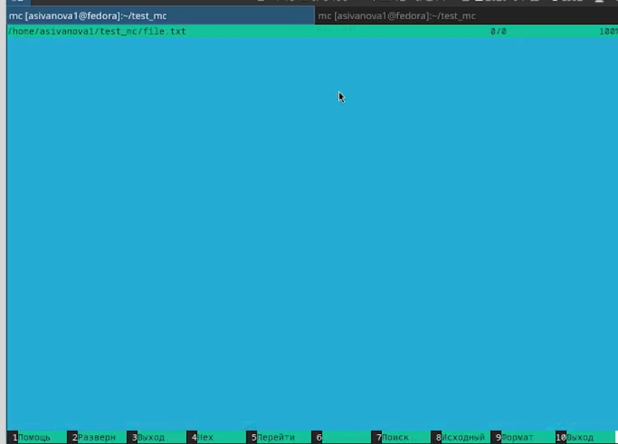

Рисунок 5: Выполнение

```
- редактирование содержимого текстового файла (без сохранения результатов редактирования)
```

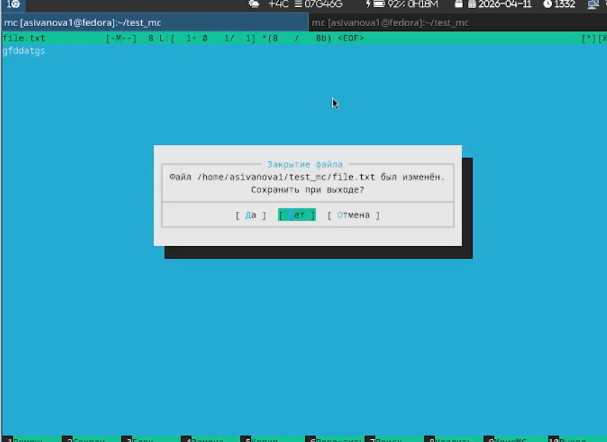

Рисунок 6: Выполнение

```
- создание каталога
```

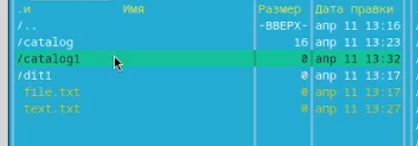

Рисунок 7: Выполнение

```
- копирование файлов в созданный каталог
```

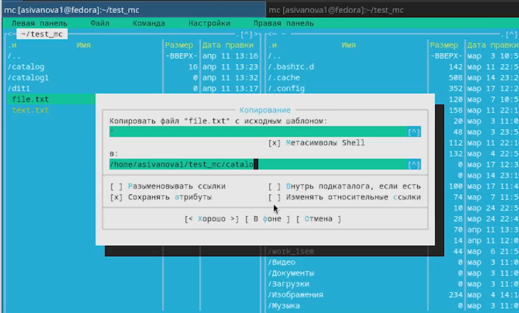

Рисунок 8: Выполнение

**5. С помощью соответствующих средств подменю Команда осуществим:**

```
- поиск в файловой системе файла с заданными условиями
```

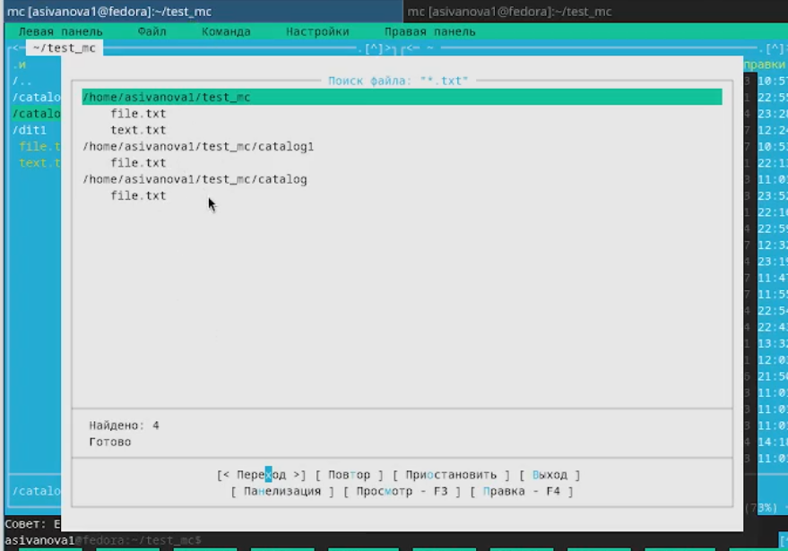

Рисунок 9: Поиск

[output not shown]

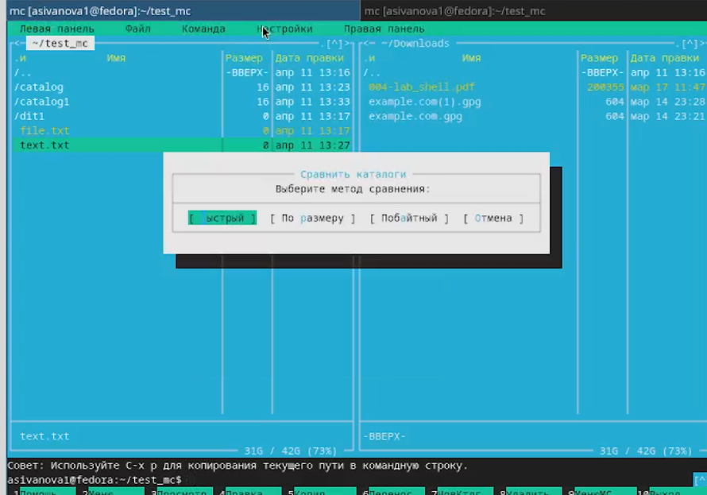

Рисунок 10: Анализ

**6. Вызовем подменю Настройки. Освоим операции, определяющие структуру экрана mc (Full screen, Double Width, Show Hidden Files и т.д.).**

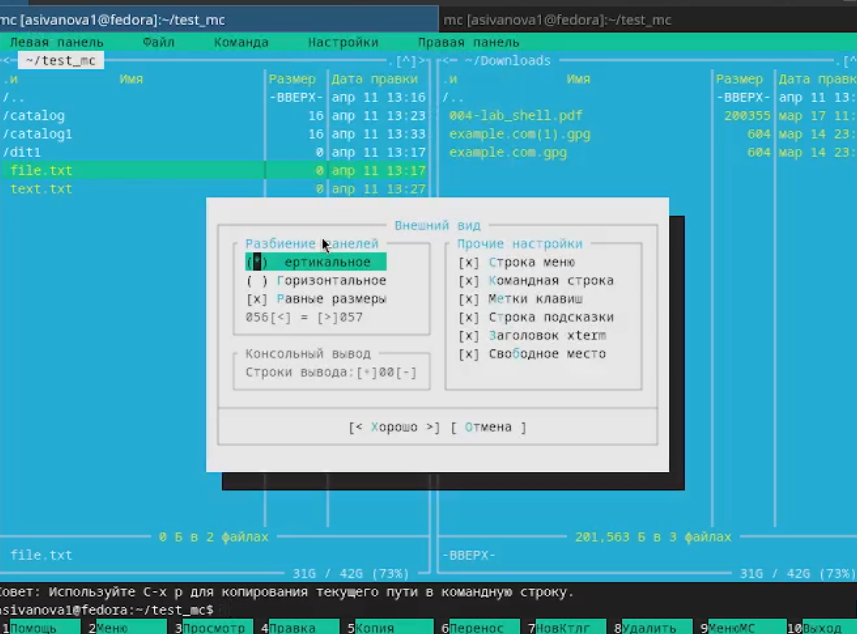

Рисунок 11: Выполнение

**7. Задание по встроенному редактору mc:**

1. Создадим текстовой файл text.txt и откроем его

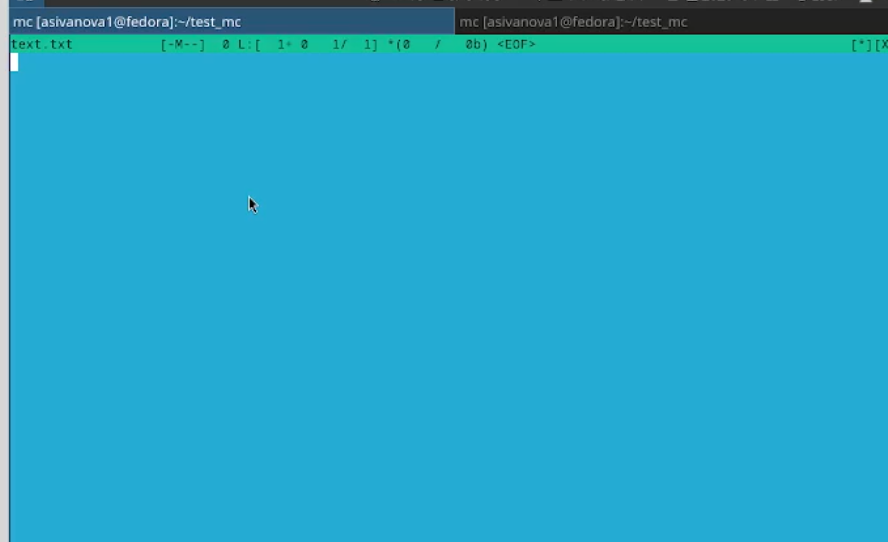

Рисунок 12: Создание

2. Вставим в открытый файл небольшой фрагмент текста, скопированный из любого другого файла или Интернета

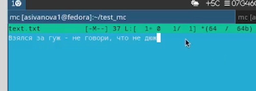

Рисунок 13: Вставка

3. Проделаем с текстом следующие манипуляции, используя горячие клавиши:

   3.1) Удалим строку текста

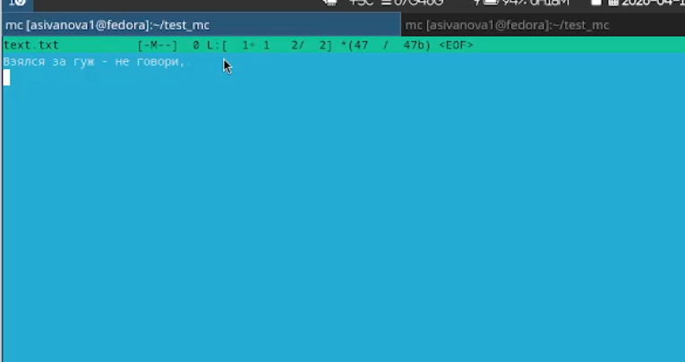

Рисунок 14: Выполнение

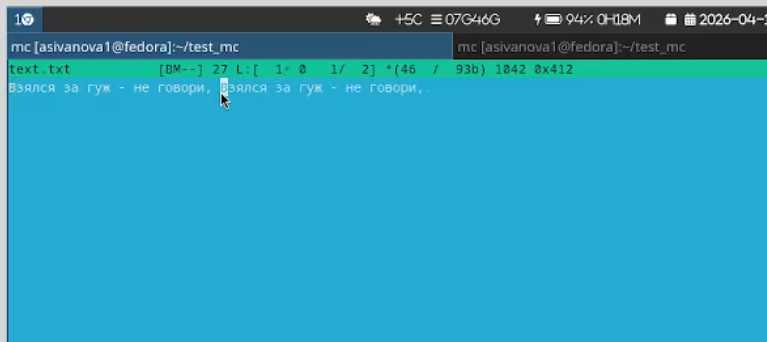

Рисунок 15: Выполнение

3.3) Выделим фрагмент текста и перенесём его на новую строку

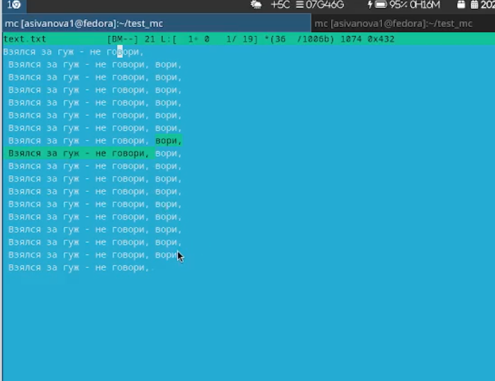

Рисунок 16: Выполнение

3.4) Отменим последнее действие

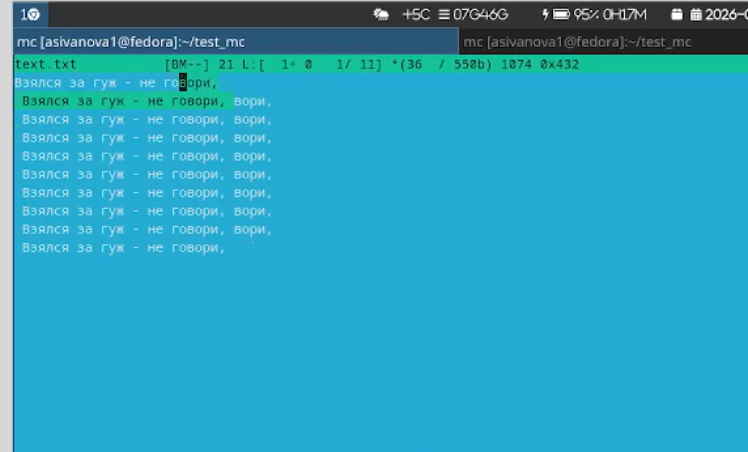

Рисунок 17: Выполнение

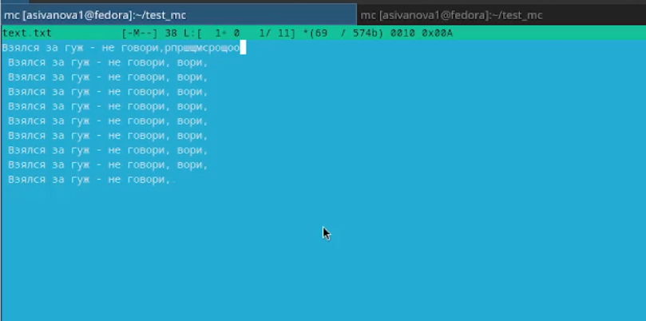

Рисунок 18: Выполнение

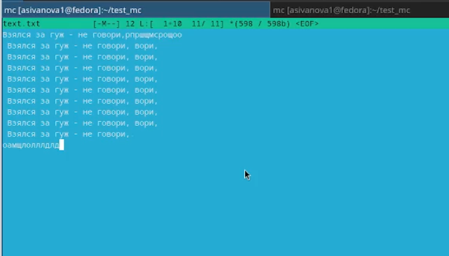

Рисунок 19: Выполнение

3.7) Сохраним и закроем файл

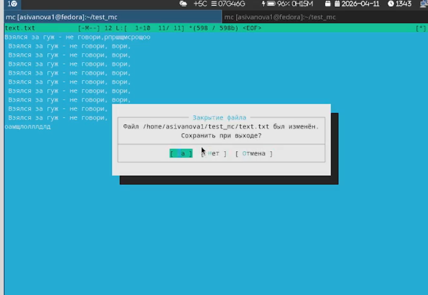

Рисунок 20: Выполнение

4. Откроем файл с исходным текстом на некотором языке программирования (например C или Java)

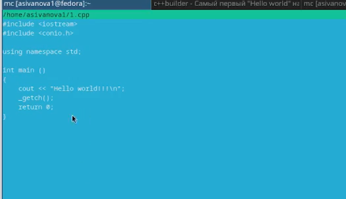

Рисунок 21: Выполнение

5. Используя меню редактора, включим подсветку синтаксиса, если она не включена, или выключим, если она включена

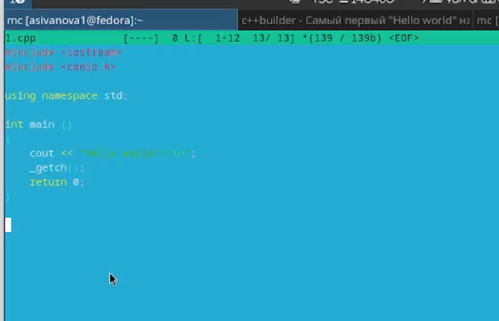

Рисунок 22: Выполнение

## **Контрольные вопросы**

**1. Какие режимы работы есть в mc? Охарактеризуйте их.**

- **Панельный режим** — основной режим, отображаются две панели с файлами
- **Режим информации** — на панели отображается информация о текущем файле и файловой системе
- **Режим дерева** — на панели отображается структура дерева каталогов

**2. Какие операции с файлами можно выполнить как с помощью команд shell, так и с помощью меню (комбинаций клавиш) mc? Приведите несколько примеров.**

| Операция | Команда shell | В mc |
| --- | --- | --- |
| Копирование | `cp file1 file2` | `F5` |
| Перемещение | `mv file1 dir/` | `F6` |
| Удаление | `rm file` | `F8` |
| Создание каталога | `mkdir dir` | `F7` |

**3. Опишите структура меню левой (или правой) панели mc, дайте характеристику командам.**

- **Список** — отображение содержимого каталога
- **Дерево** — отображение дерева каталогов
- **Информация** — информация о текущем файле
- **Формат списка** — настройка отображения (стандартный, укороченный, расширенный)
- **Сортировка** — по имени, времени, размеру
- **Фильтр** — отображение только определённых файлов

**4. Опишите структура меню Файл mc, дайте характеристику командам.**

- **Просмотр** (`F3`) — просмотр содержимого файла
- **Редактирование** (`F4`) — редактирование файла
- **Копирование** (`F5`) — копирование файлов
- **Перемещение** (`F6`) — перемещение/переименование
- **Создание каталога** (`F7`) — создание нового каталога
- **Удаление** (`F8`) — удаление файлов/каталогов
- **Права доступа** (`Ctrl+x` → `c`) — изменение прав доступа
- **Символическая ссылка** (`Ctrl+x` → `s`) — создание ссылки

**5. Опишите структура меню Команда mc, дайте характеристику командам.**

- **Поиск файлов** — поиск файлов по имени и содержимому
- **История команд** — просмотр и повтор команд
- **Каталоги быстрого доступа** — быстрый переход в часто используемые каталоги
- **Редактировать файл меню** — настройка пользовательского меню (`~/.mc/menu`)
- **Редактировать файл расширений** — настройка действий для файлов по расширениям (`~/.mc/ext`)

**6. Опишите структура меню Настройки mc, дайте характеристику командам.**

- **Внешний вид** — настройка отображения панелей, цветов
- **Настройки панелей** — настройка отображения файлов, показ скрытых файлов
- **Подтверждение** — запрос подтверждения при удалении, перезаписи
- **Распознавание клавиш** — тестирование функциональных клавиш
- **Виртуальная файловая система** — настройка работы с архивами и сетью

**7. Назовите и дайте характеристику встроенным командам mc.**

- `cd` — смена текущего каталога
- `pwd` — показать текущий каталог
- `ls` — просмотр содержимого
- `cp` — копирование
- `mv` — перемещение
- `rm` — удаление
- `mkdir` — создание каталога

**8. Назовите и дайте характеристику командам встроенного редактора mc.**

| Команда | Действие |
| --- | --- |
| `Ctrl + y` | Удалить строку |
| `F5` | Копировать выделенное |
| `F6` | Вырезать/переместить выделенное |
| `F2` | Сохранить файл |
| `F10` | Выйти из редактора |
| `Ctrl + u` | Отменить последнее действие |
| `Ctrl + Home` | Перейти в начало файла |
| `Ctrl + End` | Перейти в конец файла |
| `Ctrl + s` | Включить/выключить подсветку синтаксиса |

**9. Дайте характеристику средствам mc, которые позволяют создавать меню, определяемое пользователем.**

Файл `~/.mc/menu` — пользовательское меню, вызываемое клавишей `F2`. Позволяет добавлять свои команды для выполнения над файлами. Формат:

```
M + 1=Команда
    Выполняемая команда
```

**10. Дайте характеристику средствам mc, которые позволяют выполнять действия, определяемые пользователем, над текущим файлом.**

Файл `~/.mc/ext` — файл расширений, определяет действия для файлов по расширению. Например, для `*.c` можно задать компиляцию при нажатии `F3`. Формат:

```
regex/\.c$
    Open=команда
    View=команда для просмотра
```

# **Вывод**

Мы освоили основных возможностей командной оболочки Midnight Commander, приобрели навыков практической работы по просмотру каталогов и файлов; манипуляций с ними.